# HOMEWORK 4

Abdullah Aladağ - IE582 - Fall 2020

# Communities and Crime Data Set

The data combines socio-economic data from the 1990 US Census, law enforcement data from the 1990 US LEMAS survey, and crime data from the 1995 FBI UCR.

### Feature Information

Many variables are included so that algorithms that select or learn weights for attributes could be tested. The variables included in the dataset involve the community, such as the percent of the population considered urban, and the median family income, and involving law enforcement, such as per capita number of police officers, and percent of officers assigned to drug units.

Data is described below based on original values. All numeric data was normalized into the decimal range 0.00-1.00 using an Unsupervised, equal-interval binning method. Attributes retain their distribution and skew (hence for example the population attribute has a mean value of 0.06 because most communities are small). E.g. An attribute described as ‘mean people per household’ is actually the normalized (0-1) version of that value. Some features names are listed below.

**Features**

state numeric

county numeric

community numeric

communityname string

fold numeric

population numeric

householdsize numeric

racepctblack numeric

racePctWhite numeric

racePctAsian numeric

racePctHisp numeric

….

**Target**

ViolentCrimesPerPop numeric

```r
# Install packages and Import library

library("caret")
library("dplyr")
library("glmnet")
library(Metrics)
require(rpart)
library(rattle)
library(RColorBrewer)
require(data.table,quietly = TRUE)
library(data.table)
library(randomForest)
library(gbm)
library(xgboost)
library(e1071)
```

```r
setwd("C:/Users/asus/Desktop")


all_data = read.table("communities.csv", sep = ",", na.strings = c("?","NA") )
communities = all_data[,-4]

colnames(communities)[ncol(communities)] = "violent_crimes"
```

```r
# replace NA values with their mean values

for(i in 1:ncol(communities)){

  communities[,i][is.na(communities[,i])] <- round(mean(communities[,i], na.rm = TRUE))
}
```

```r
# split whole data as training and test set
set.seed(121)
idx <- sample(seq(1, 2), size = nrow(communities), replace = TRUE, prob = c(.75, .25))

train_comm <- communities[idx == 1,]
test_comm <- communities[idx == 2,]
```

## Penalized Linear Regression

In this part, PLR is applied to the data. Different lambda values are tried to catch the best test accuracy.

```r
# apply penalized linear regression


PRA = function(lambda){

  glmmod = glmnet(as.matrix(train_comm[,1:(ncol(train_comm)-1)]),train_comm$violent_crimes, family = "gaussian",type.measure = "mae",trcontrol = control)



  # for test set


  prediction_test = predict(glmmod,as.matrix(test_comm[,1:(ncol(test_comm)-1)]),s = lambda)
  test_error= smape(test_comm$violent_crimes,prediction_test)

  train_prediction<- predict(glmmod,as.matrix(train_comm[,1:(ncol(test_comm)-1)]),s = lambda)
  error_train <- smape(train_comm$violent_crimes,train_prediction)


  plot(test_comm$violent_crimes,prediction_test, xlab = "Actual Value", ylab= "Predicted", main = paste(" Penalized Linear Regression with",lambda))
  abline(a=0,b =1, col = 2)
  print(paste("Accuracy for test data", 1-test_error))
  print(paste("Accuracy for training data", 1-error_train))

 }
```

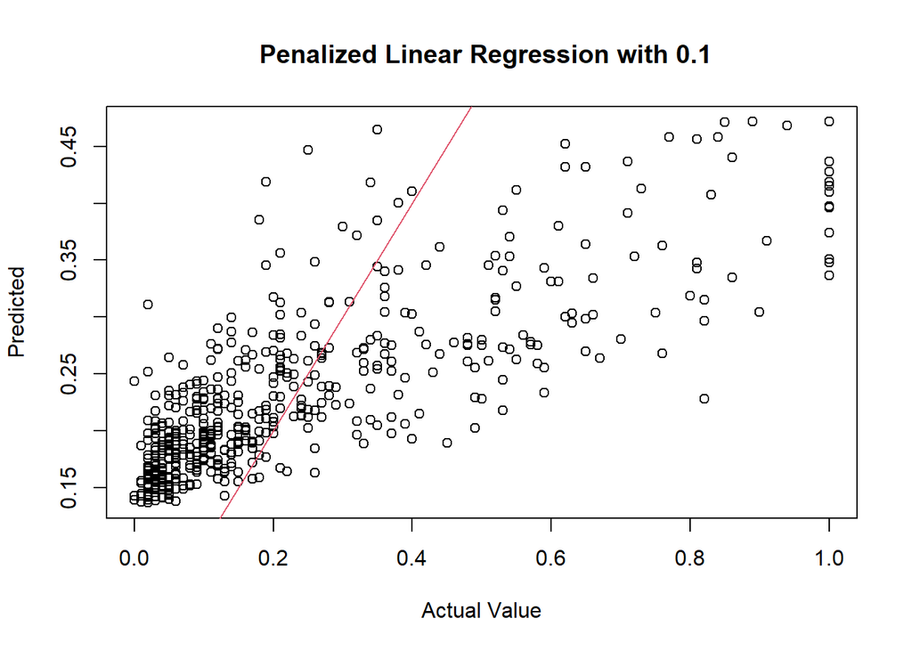

```
## [1] "Accuracy for test data 0.308350419478901"
## [1] "Accuracy for training data 0.337820445879606"
```

```r
# Penalized Linear Regression with lambda 0.1
PRA(0.1)
```

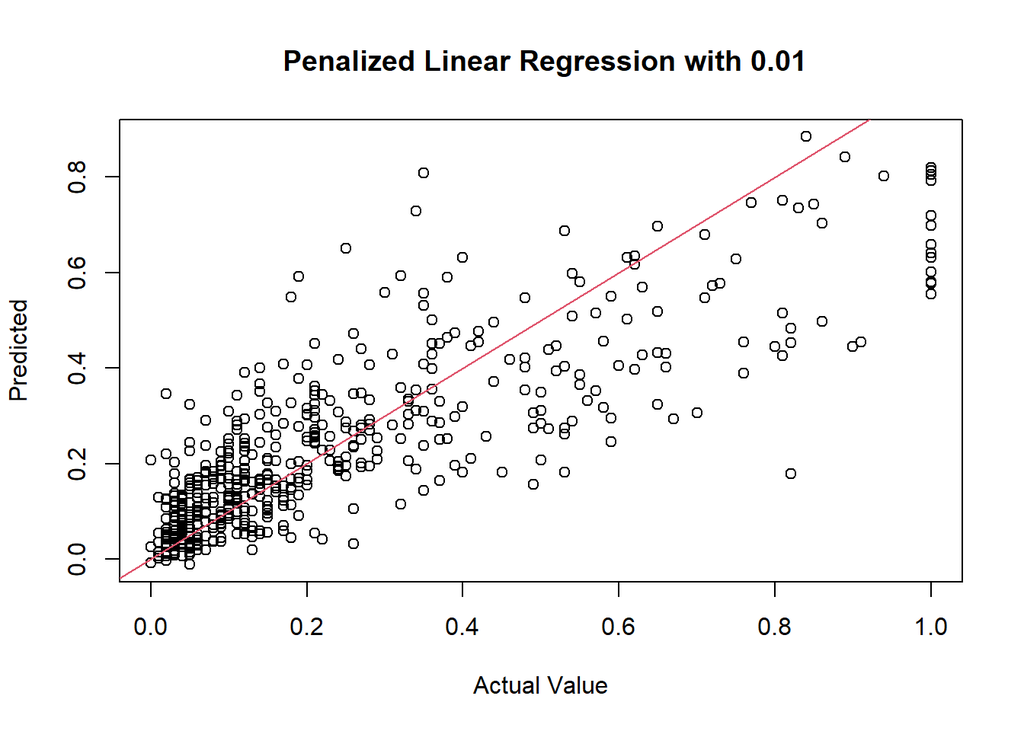

```
## [1] "Accuracy for test data 0.487194104815934"
## [1] "Accuracy for training data 0.506081341008665"
```

```r
# Penalized Linear Regression with lambda 0.01
PRA(0.01)
```

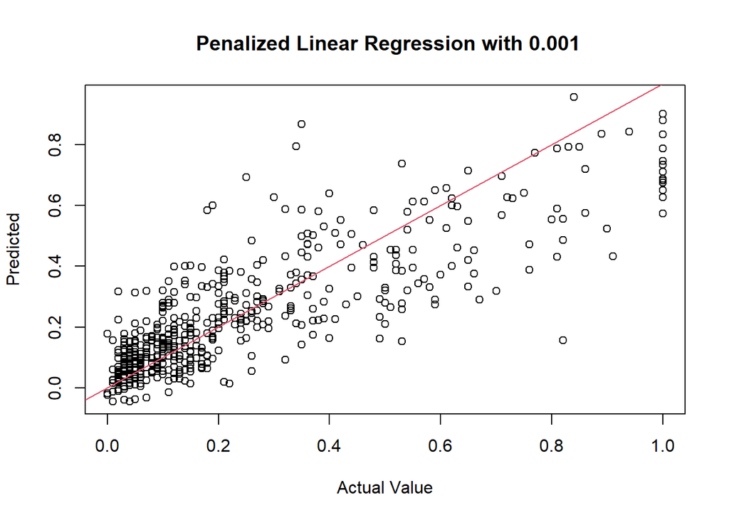

```
## [1] "Accuracy for test data 0.464272396757754"
## [1] "Accuracy for training data 0.484492267203526"
```

```r
# Penalized Linear Regression with lambda 0.001
PRA(0.001)
```

## Regression Tree

```r
# Regression Tree

Decision_tree <- function(cp,minsplit){

  Reg_tree = rpart(violent_crimes~.,train_comm, method = "anova",cp = cp, minsplit = minsplit)



  test_prediction= predict(Reg_tree,test_comm)
  test_error= smape(test_comm$violent_crimes,test_prediction)

  train_prediction<- predict(Reg_tree,train_comm)
  error_train <- smape(train_comm$violent_crimes,train_prediction)



  plot(test_comm$violent_crimes,test_prediction, xlab = "Actual Value", ylab= "Predicted",main = paste("Decision Tree with cp =",cp,"and Minsip =" ,minsplit))
  abline(a=0,b =1, col = 2)

  print(paste("Accuracy for test data", 1-test_error))
  print(paste("Accuracy for training data", 1-error_train))


}
```

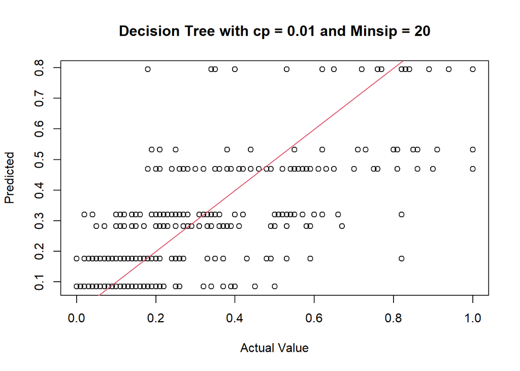

```
## [1] "Accuracy for test data 0.442762034806052"
## [1] "Accuracy for training data 0.47681415136221"
```

```r
Decision_tree(cp = 0.01, minsplit =20)
```

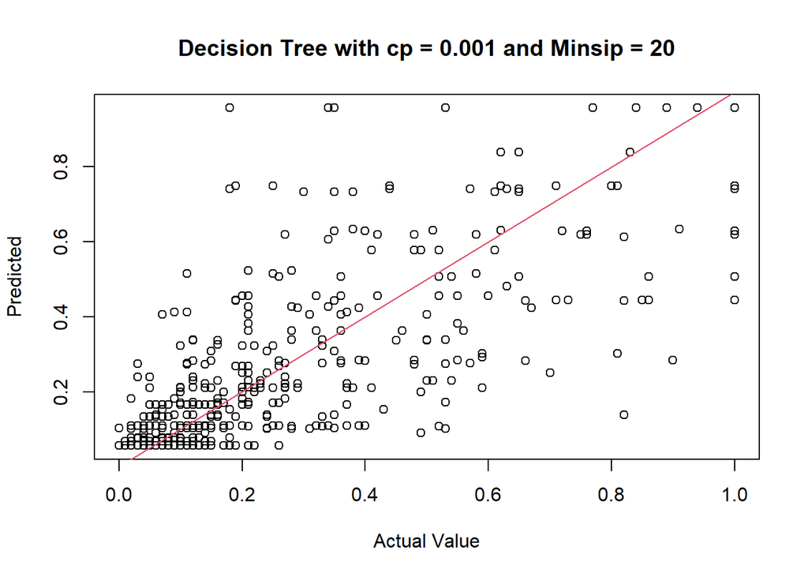

```
## [1] "Accuracy for test data 0.479573608253357"
## [1] "Accuracy for training data 0.593913306844993"
```

```r
Decision_tree(cp = 0.001, minsplit =20)
```

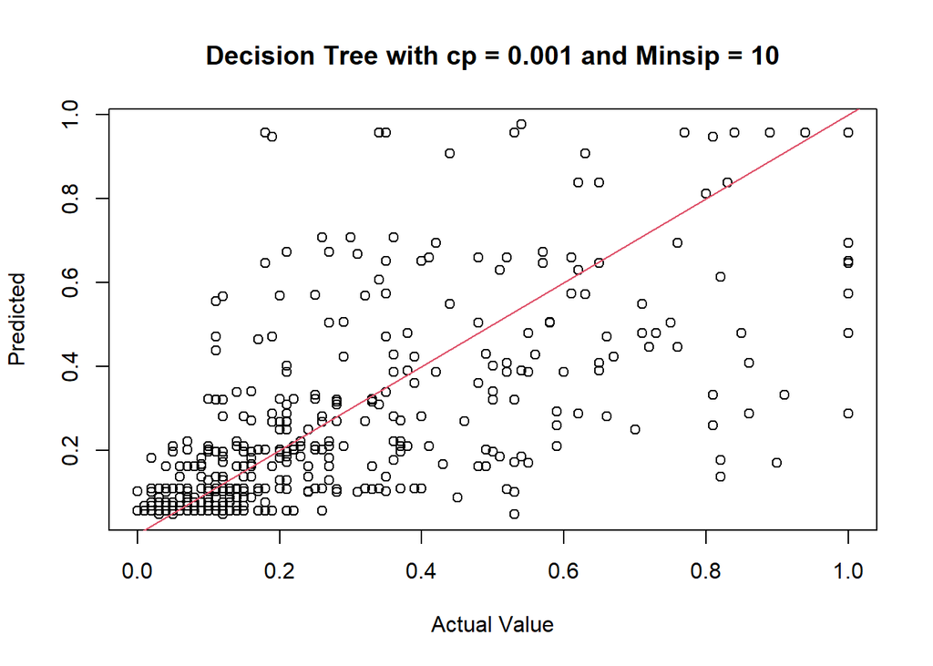

```
## [1] "Accuracy for test data 0.470287485402064"
## [1] "Accuracy for training data 0.622225441213383"
```

```r
Decision_tree(cp = 0.001, minsplit = 10)
```

## Random Forest

```r
##Random forest

Random_forest <- function(numfeat){
  RF = randomForest(train_comm[,1:(ncol(train_comm)-1)],train_comm$violent_crimes, mtry = numfeat )
  print(RF)

  # Test data
  prediction_test = predict(RF,test_comm)
  test_error = smape(prediction_test,test_comm$violent_crimes)

  train_prediction<- predict(RF,train_comm)
  error_train <- smape(train_comm$violent_crimes,train_prediction)


  plot(test_comm$violent_crimes, prediction_test, main = "Random Forest",xlab = "Actual Value", ylab= "Predicted")
  abline(a=0 ,b=1, col =2)
  print(paste("Accuracy for test data", 1-test_error))
  print(paste("Accuracy for training data", 1-error_train))



}
```

```r
Random_forest(20)
```

```
##
## Call:
##  randomForest(x = train_comm[, 1:(ncol(train_comm) - 1)], y = train_comm$violent_crimes,      mtry = numfeat)
##                Type of random forest: regression
##                      Number of trees: 500
## No. of variables tried at each split: 20
##
##           Mean of squared residuals: 0.01839619
##                     % Var explained: 64.98
```

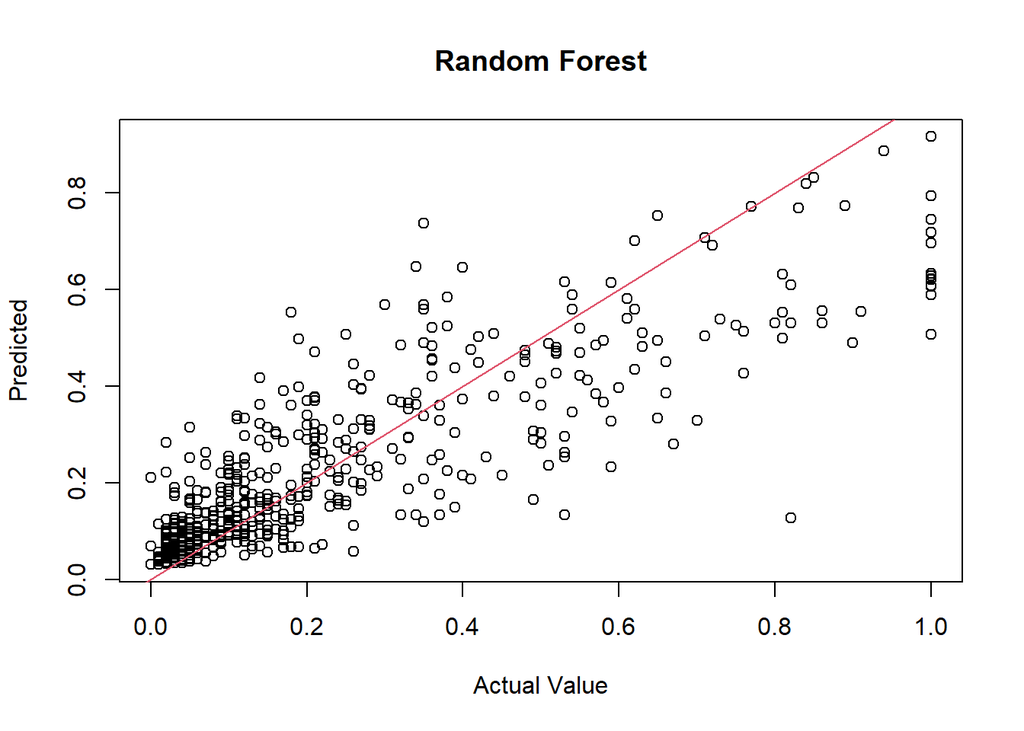

```
## [1] "Accuracy for test data 0.517625036988603"
## [1] "Accuracy for training data 0.765242583005079"
```

```r
Random_forest(15)
```

```
##
## Call:
##  randomForest(x = train_comm[, 1:(ncol(train_comm) - 1)], y = train_comm$violent_crimes,      mtry = numfeat)
##                Type of random forest: regression
##                      Number of trees: 500
## No. of variables tried at each split: 15
##
##           Mean of squared residuals: 0.0184414
##                     % Var explained: 64.89
```

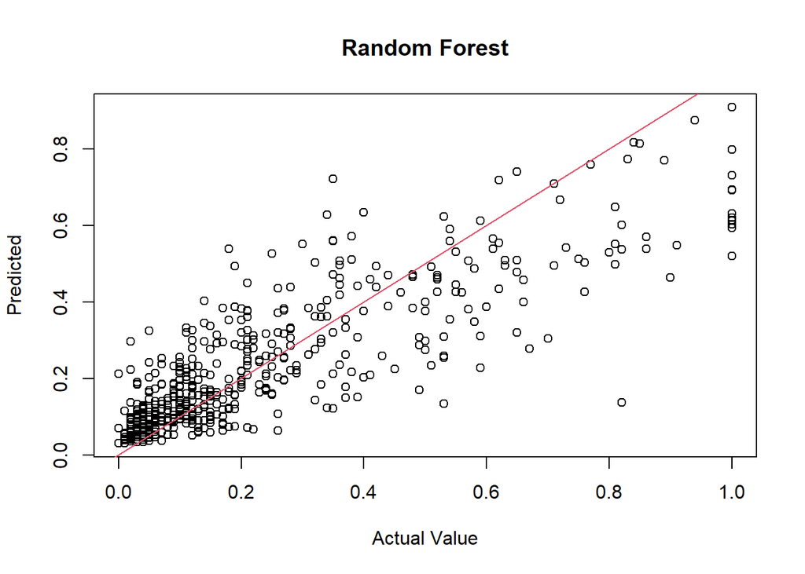

```
## [1] "Accuracy for test data 0.51604787185785"
## [1] "Accuracy for training data 0.763215128015127"
```

```r
Random_forest(30)
```

```
##
## Call:
##  randomForest(x = train_comm[, 1:(ncol(train_comm) - 1)], y = train_comm$violent_crimes,      mtry = numfeat)
##                Type of random forest: regression
##                      Number of trees: 500
## No. of variables tried at each split: 30
##
##           Mean of squared residuals: 0.01850125
##                     % Var explained: 64.78
```

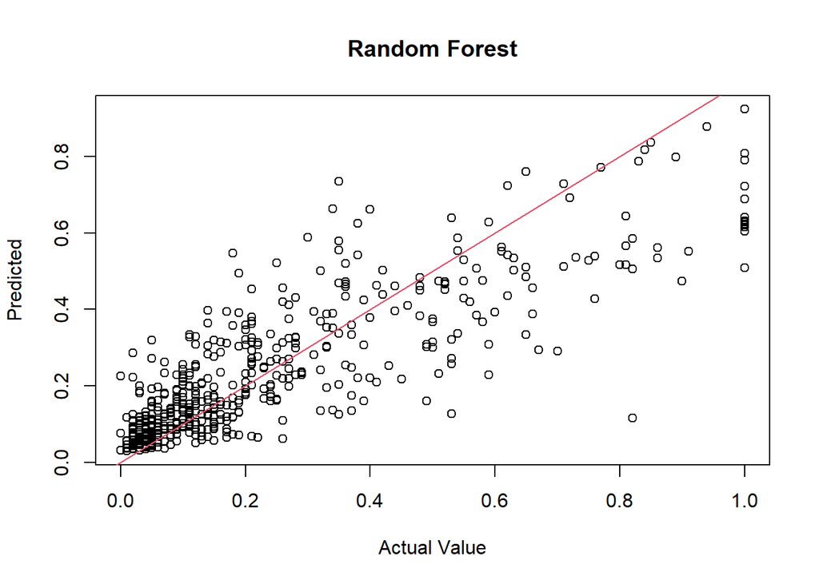

```
## [1] "Accuracy for test data 0.519750031051035"
## [1] "Accuracy for training data 0.767052489671499"
```

Random forest use many trees to predict target values. Therefore, it is expected to get better results than regression trees. Results met this expectation.The best results was achieved when number of features which are choosen randomly as splitting feature was equal to 30.Random forest tends to be overfitting because many trees are used. Overfitting was observed as expected(training accuracy =0.76, test accuracy =0.5).However, random forest gave best test accuracy among others learners tried to predict target values.

## Stochastic Gradient Boosting

```r
stoc_grad_boosting <- function(alpha,depth,numtree){

  control <- trainControl(method = "repeatedcv",number = 5, repeats = 2, allowParallel = T)


  unwantedoutput <- capture.output( GBMModel <-  gbm(violent_crimes~., data = train_comm, bag.fraction = 0.7,n.trees = numtree, shrinkage = alpha,interaction.depth = depth))

  print(GBMModel)


  prediction <- predict(GBMModel,test_comm)
  test_error <- smape(prediction,test_comm$violent_crimes)

  train_prediction<- predict(GBMModel,train_comm)
  error_train <- smape(train_comm$violent_crimes,train_prediction)



  plot(test_comm$violent_crimes, prediction, main = "S. Gradient Boosting",xlab = "Actual Value", ylab= "Predicted")
  abline(a=0 ,b=1, col =2)
  print(paste("Accuracy for test data", 1-test_error))
  print(paste("Accuracy for training data", 1-error_train))
}
```

```r
stoc_grad_boosting(0.01,1,100)
```

```
## gbm(formula = violent_crimes ~ ., data = train_comm, n.trees = numtree,
##     interaction.depth = depth, shrinkage = alpha, bag.fraction = 0.7)
## A gradient boosted model with gaussian loss function.
## 100 iterations were performed.
## There were 126 predictors of which 6 had non-zero influence.
```

```
## Using 100 trees...
##
## Using 100 trees...
```

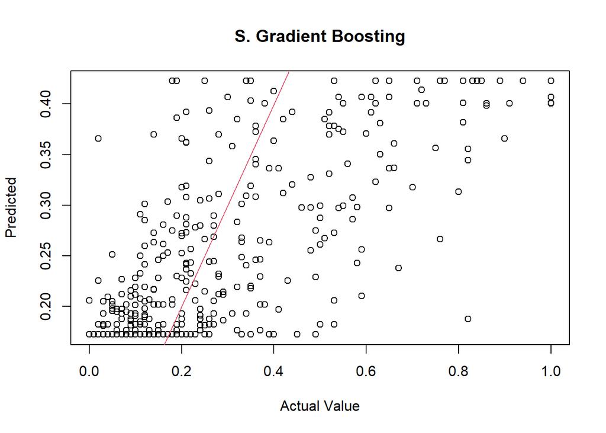

```
## [1] "Accuracy for test data 0.317417752725719"
## [1] "Accuracy for training data 0.358762600518881"
```

```r
stoc_grad_boosting(0.01,2,150)
```

```
## gbm(formula = violent_crimes ~ ., data = train_comm, n.trees = numtree,
##     interaction.depth = depth, shrinkage = alpha, bag.fraction = 0.7)
## A gradient boosted model with gaussian loss function.
## 150 iterations were performed.
## There were 126 predictors of which 20 had non-zero influence.
```

```
## Using 150 trees...
##
## Using 150 trees...
```

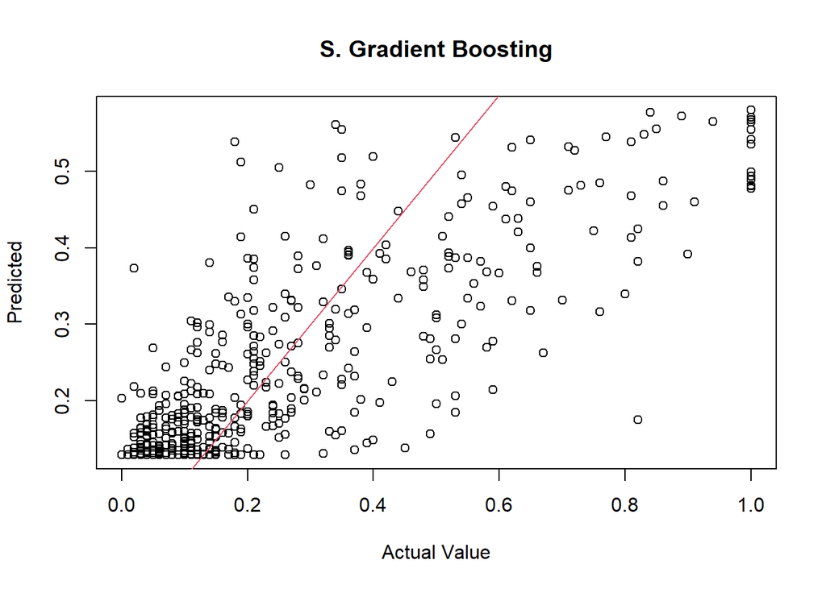

```
## [1] "Accuracy for test data 0.390629595188569"
## [1] "Accuracy for training data 0.429498929922628"
```

```r
stoc_grad_boosting(0.001,2,150)
```

```
## gbm(formula = violent_crimes ~ ., data = train_comm, n.trees = numtree,
##     interaction.depth = depth, shrinkage = alpha, bag.fraction = 0.7)
## A gradient boosted model with gaussian loss function.
## 150 iterations were performed.
## There were 126 predictors of which 7 had non-zero influence.
```

```
## Using 150 trees...
##
## Using 150 trees...
```

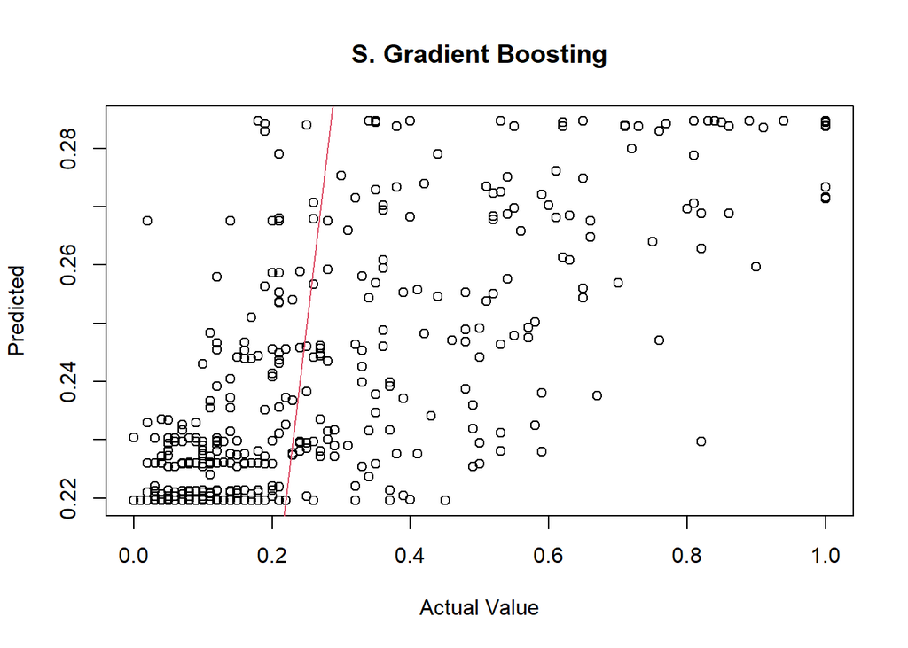

```
## [1] "Accuracy for test data 0.211789734213546"
## [1] "Accuracy for training data 0.253782809320587"
```

Stochastic gradient boosting trains model in an iterative way. it aims reducing error metrics. It gave the worst results among other learners. The best result was acquired when depth, alpha and number of trees were taken 2, 0.01 and 150.